# Caractéristiques individuelles

## Alimentation pendant la compétition

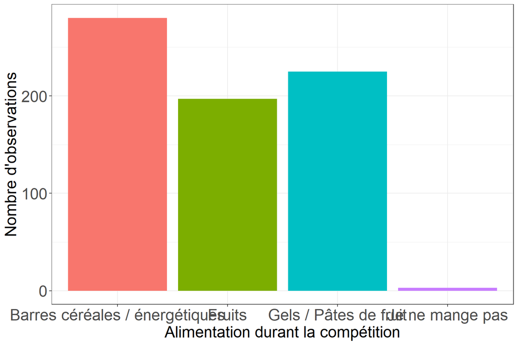

Pendant la compétition, vous mangez ?

Nous remarquons que très peu de personnes ne mangent rien durant la compétition. Concernant l’alimentation des autres, elle est répartie de manière homogène entre les barres de céréales ou énergétiques, les fruits et les gels ou pâtes de fruit.

## Fréquence d’alimentation pendant la compétition

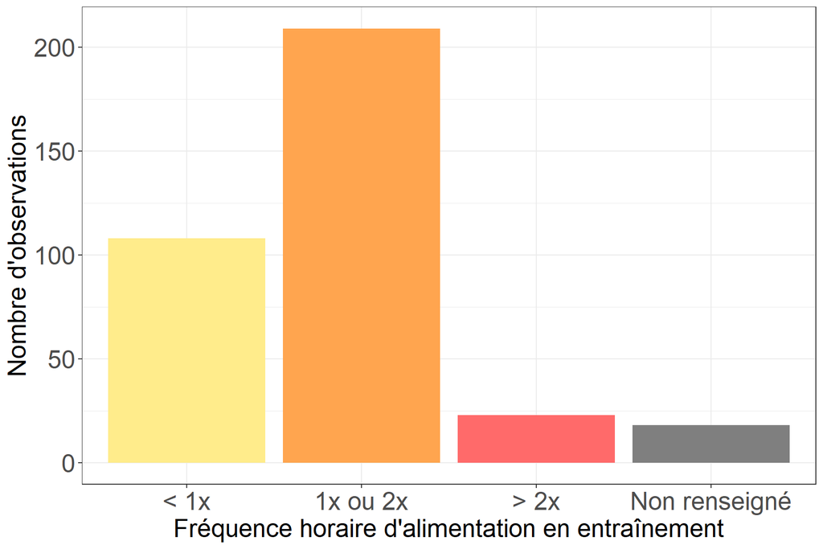

Pendant la compétition, a quelle fréquence vous mangez ?

Durant la compétition, il apparaît que les traileurs mangent majoritairement entre une et deux fois par heure.

# Santé physique

## Blessure de trail

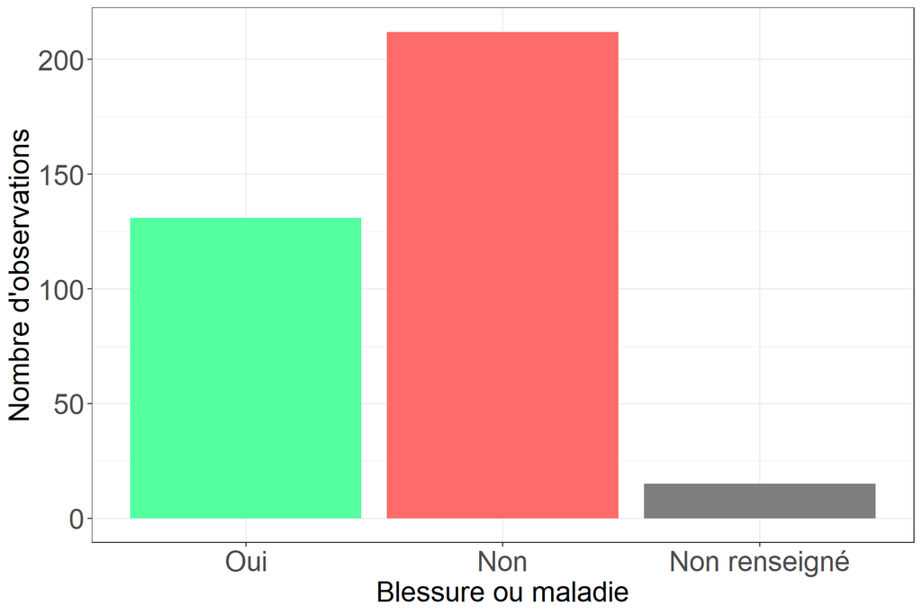

Dans l’année écoulée, avez-vous été blessé ou malade en lien avec votre pratique du trail ?

La tendance générale montre qu’une majorité des répondants n’a pas été malade ou blessée en lien avec sa pratique du trail, environ 3/5. Cependant, beaucoup de blessures et/ou maladies sont à constater, pour environ 2/5 des personnes.

## Problème de santé lié au trail

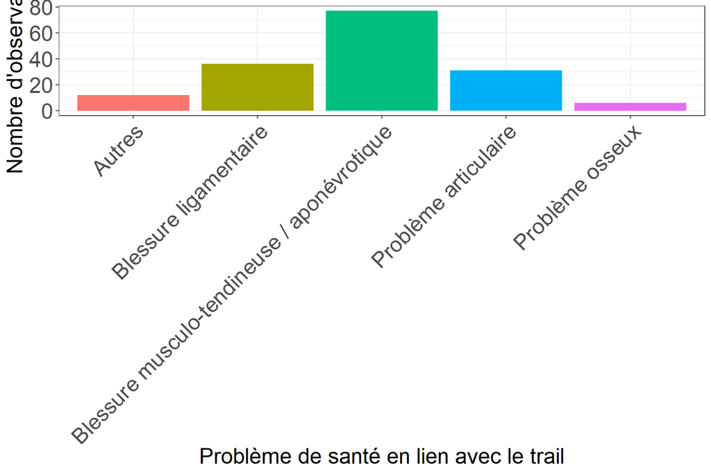

Dans l’année écoulée, parmi les problèmes de santé suivants le(s)quel.s avez-vous eu en lien avec votre pratique du trail ?

Les différents problèmes de santé observés en lien avec le trail montrent une majorité de blessures musculo-tendineuse ou aponévrotique.

## Problèmes de santé ayant empêché l’entraînement

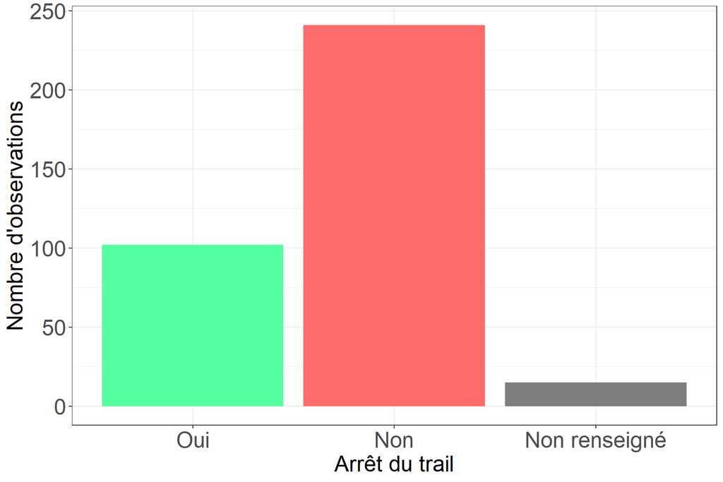

Ce.s problème.s de santé a(ont)-t-il.s entraîné une impossibilité de vous entraîner en course à pied ?

## Durée d’empêchement d’entraînement pour cause de blessure

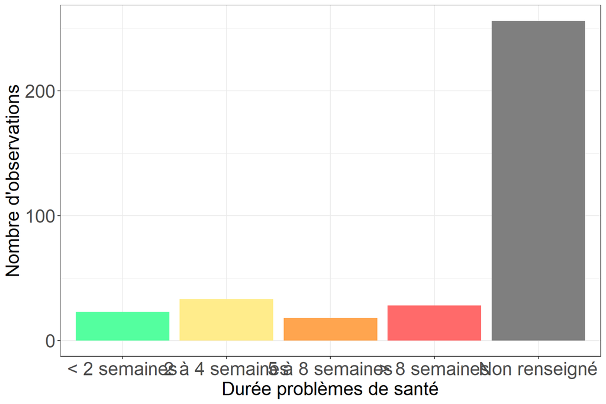

Pendant combien de temps ce.s problème.s de santé a(ont)-t-il.s entraîné une impossibilité de vous entraîner en course à pied ?

Concernant la question de la durée d’impossibilité de s’entraîner en course à pied, les réponses sont réparties de manière homogène selon les différents choix de réponse.

## Fréquence des rendez-vous médicaux

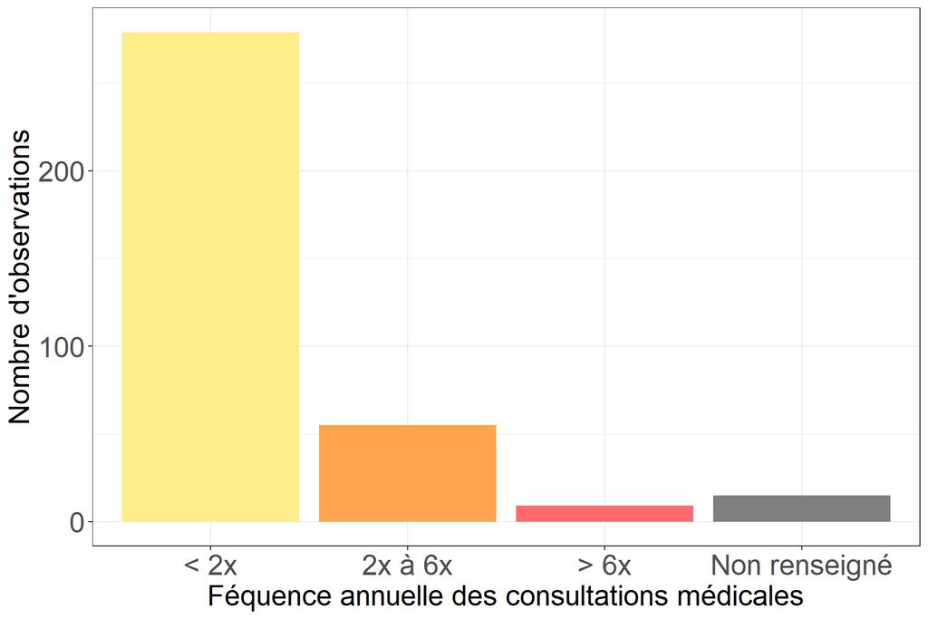

A quelle fréquence consultez-vous un médecin et/ou personnel de santé en lien avec votre pratique du trail ?

Nous observons globalement peu de consultations médicales annuelles, une majorité s’y rend moins de 2X par an.

## Raison des visites médicales

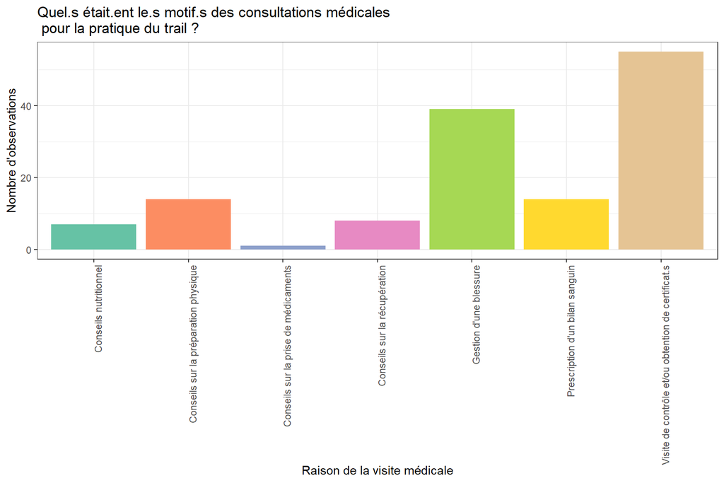

On constate que la majeure partie des visites médicales sont liées à une demande certificat ou pour la gestion d’un blessure, très peu sont liées à la prise d’un traitement. Les autres raisons sont réparties de façon relativement homogène.

## Pathologies

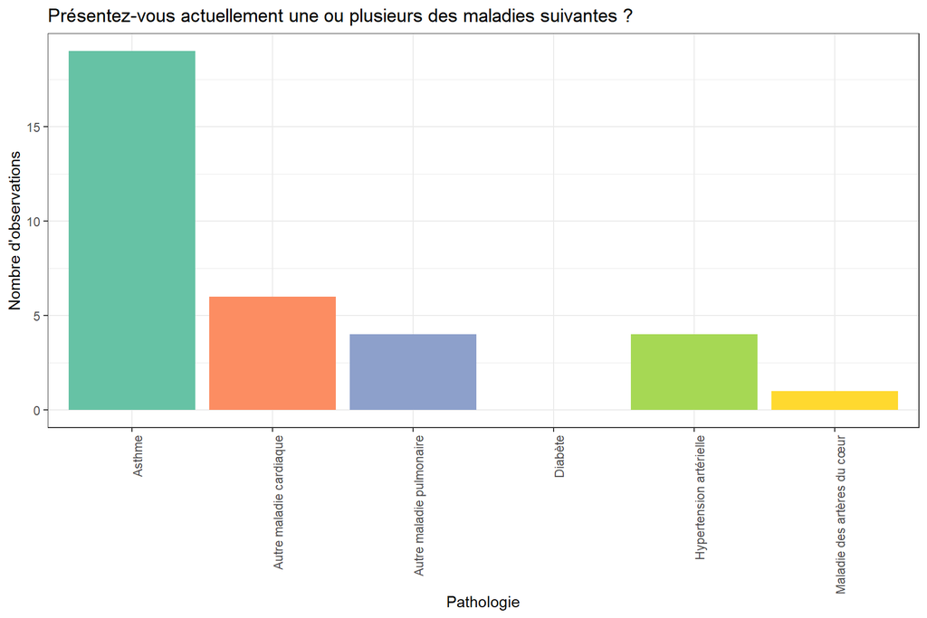

Il n’y a aucun des répondants qui a du diabète. La majorité des coureurs ayant une pathologie ont de l’asthme.

## Statut tabagique

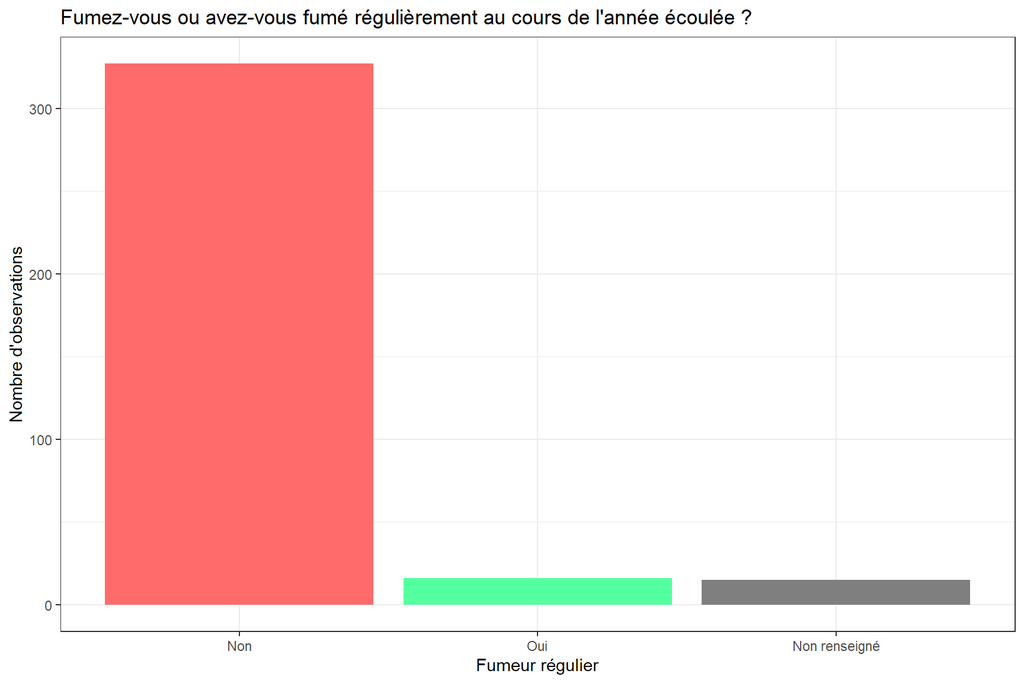

Très peu de coureurs sont des fumeurs réguliers. Cependant il est possible d’observer un biais de réponse à cette question. Le sportifs ont tendance à ne pas dire qu’ils fument dans un questionnaire malgré que cela puisse être le cas.

# Caractéristiques psychologiques

## Epanouissement

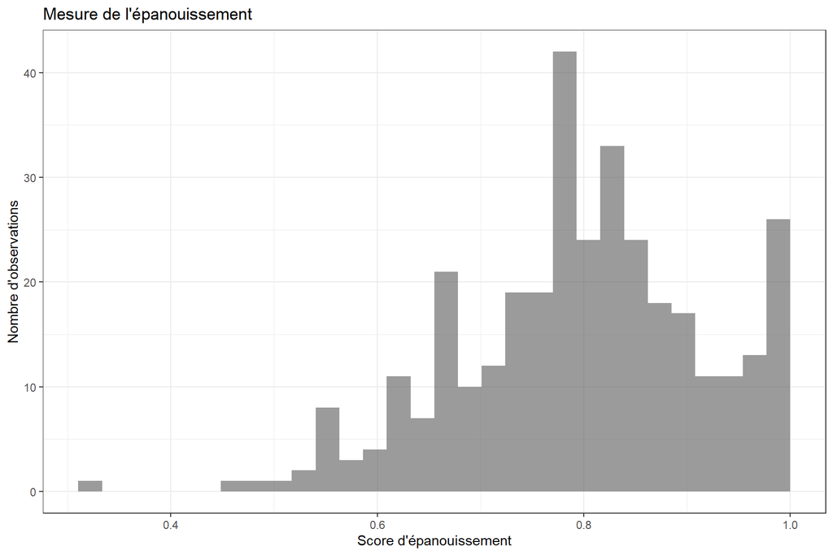

Les coureurs semblent globalement épanouis.

## Priorités

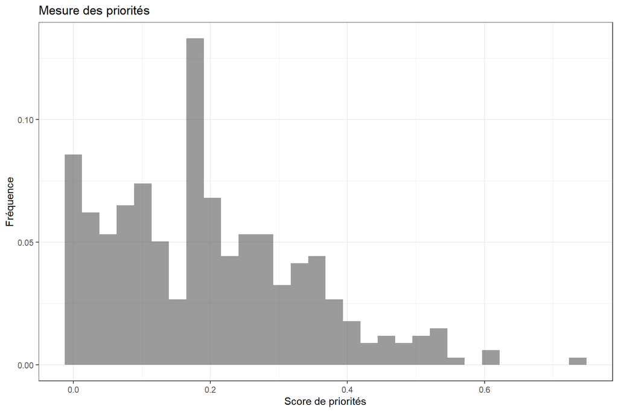

La pratique du trail ne gène pas leur vie quotidienne, ce n’est pas leur priorité, ils arrivent a bien gérer leur vie personnelle en parallèle de leur pratique.

## Motivation intrinsèque

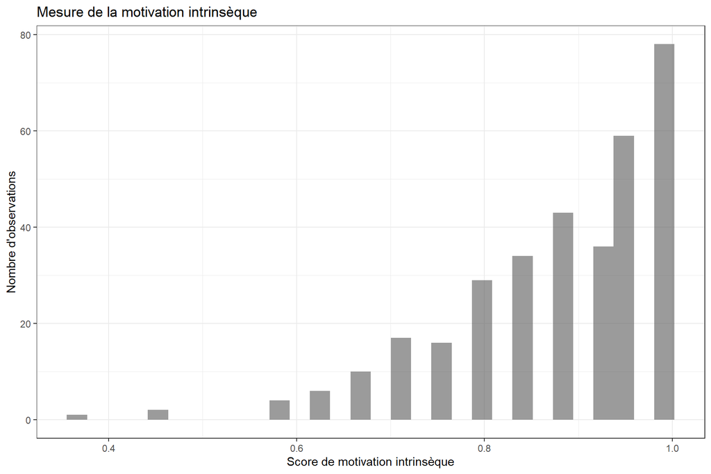

Beaucoup de coureurs pratiquent le trail avec plaisir et par envie personnelle.

## Motivation identifiée

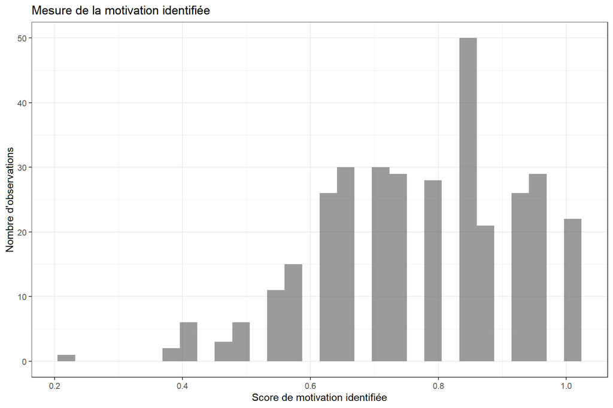

La pratique du trail leur apporte du positif, donne un sens a leur vie.

## Motivation intégrée

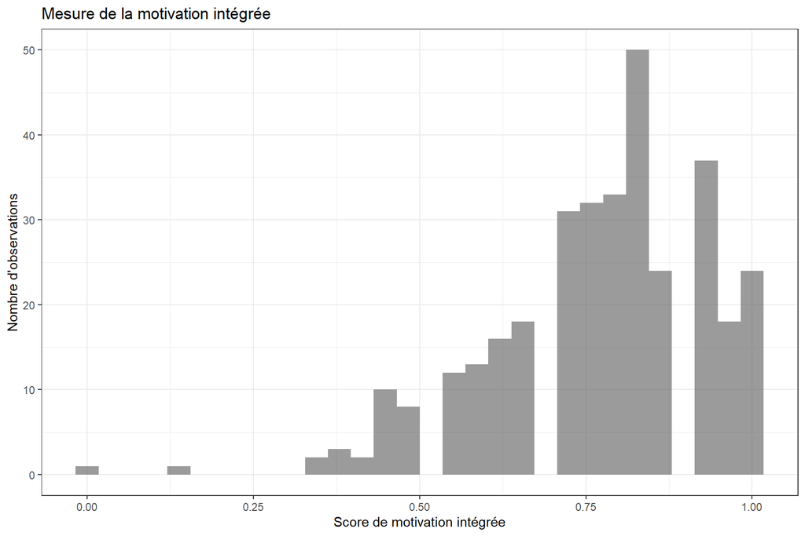

Selon les coureurs, le trail est un sport qui leur apporte vraiment, il fait parti de leur identité.

## Motivation introjectée

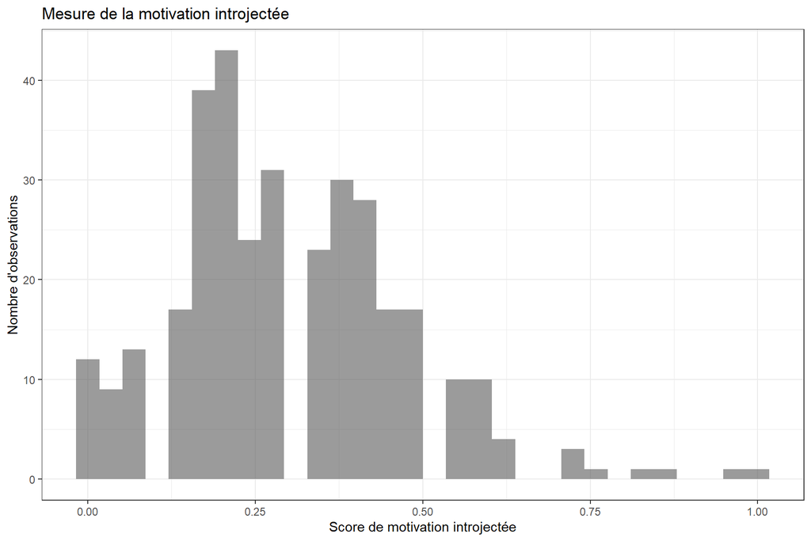

La motivation des coureurs à continuer le trail ne vient pas de la peur des conséquences de leur arrêt de la pratique.

## Motivation externe

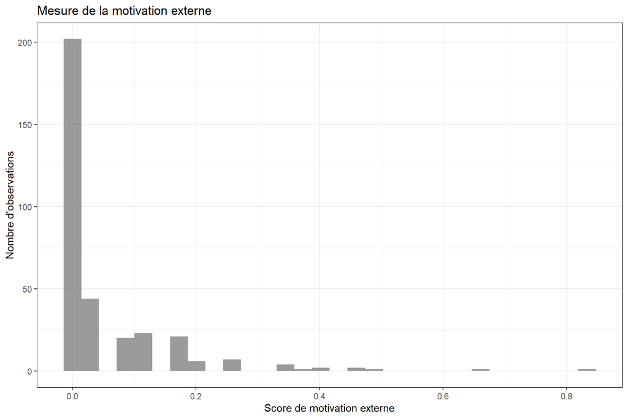

La motivation des coureurs n’est vraiment pas d’origine externe mais purement d’origine interne.

## Force mentale générale

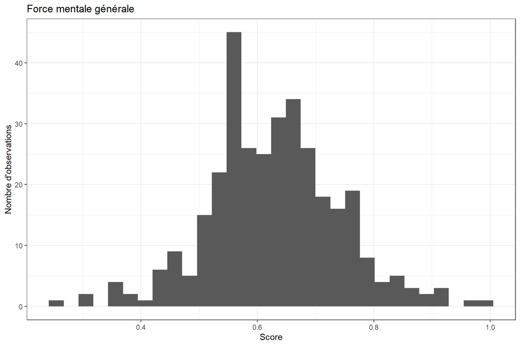

On remarque une force mentale générale moyennement haute.

## Confiance

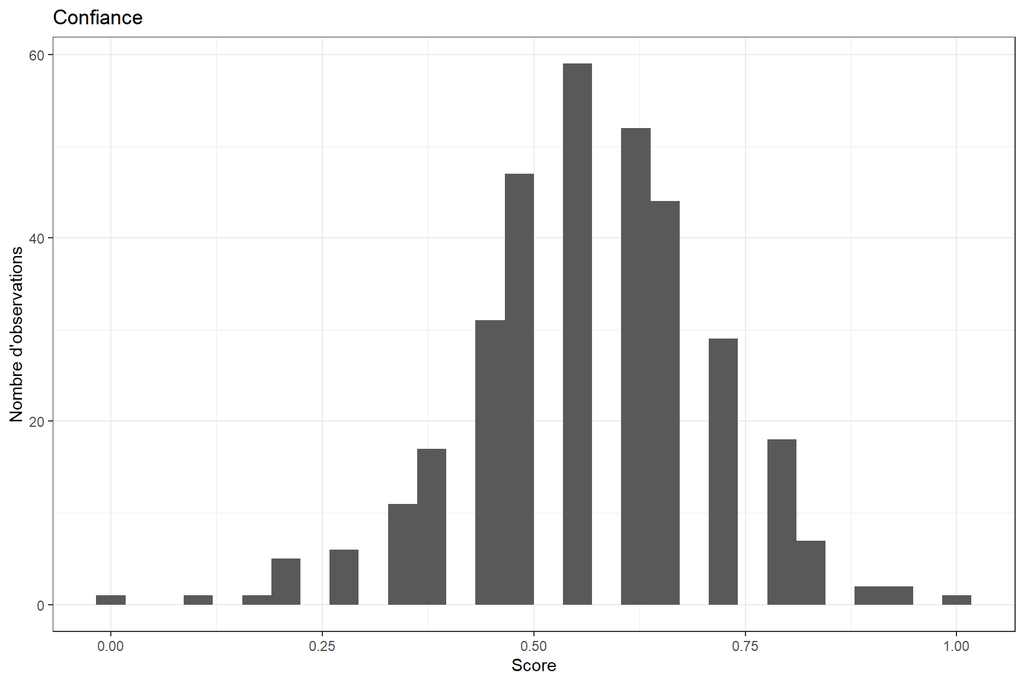

Les coureurs ont une confiance en eux moyennement haute.

## Consistence

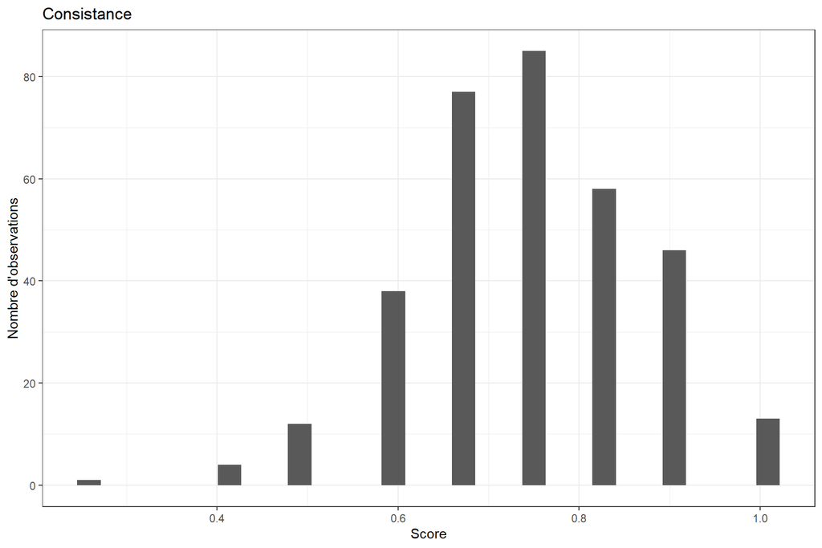

Les coureurs sont plutôt ambitieux et concentré dans le but d’atteindre leur objectifs.

## Contôle

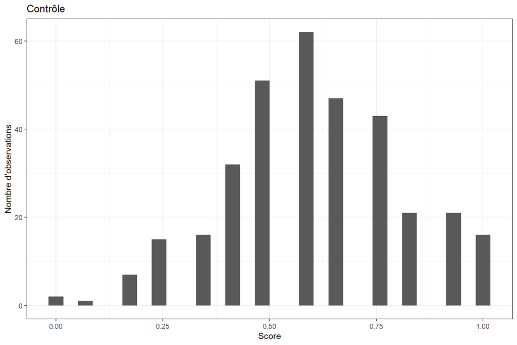

Les coureurs contôlent moyennement leurs émotions, ils se laissent un peu submerger par certaines.

## Discours interne en général

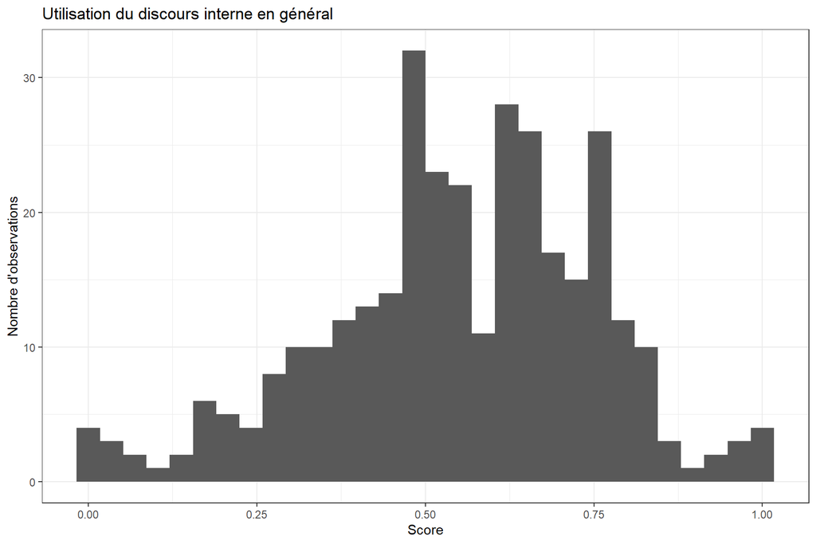

Les coureurs se parlent plutôt positivement.

## Discours interne en compétition

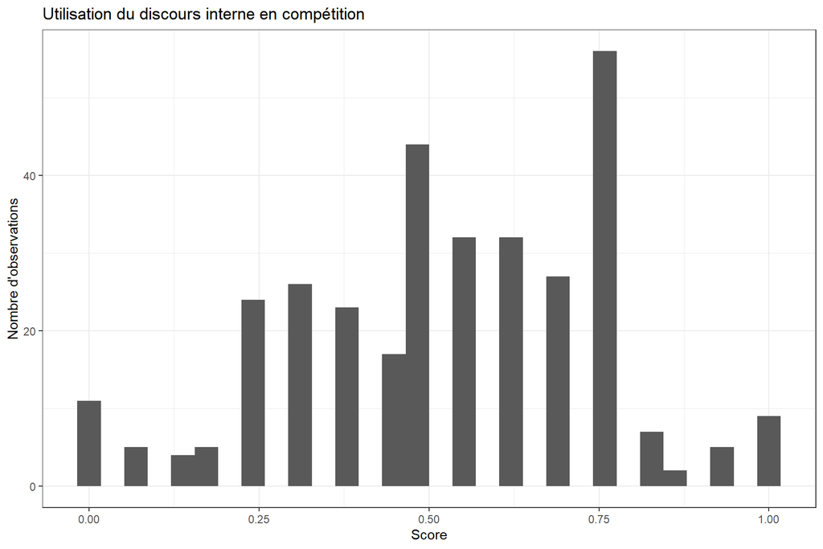

Les coureurs ont recours au discours interne pour parvenir aux compétitions.

## Discours interne à l’entrainement

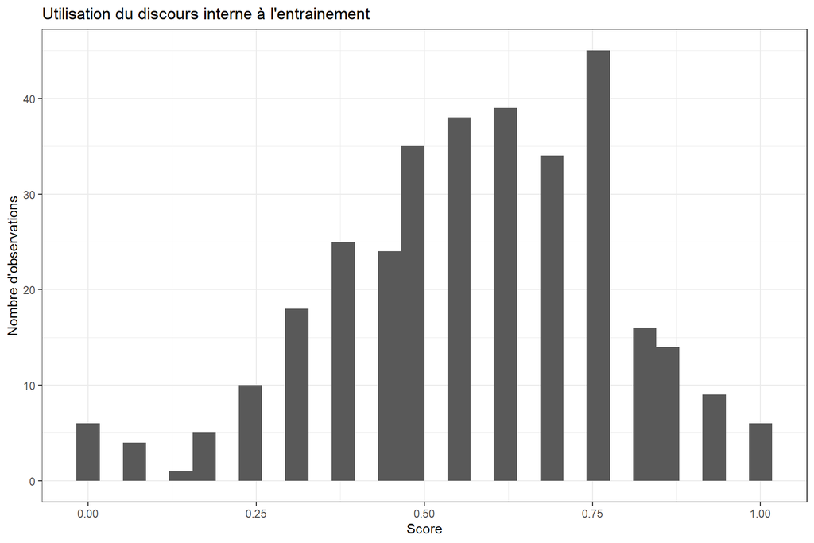

Ils ont un peu moins recours au discours interne lors des entrainements.

## Anxiété générale avant compétition

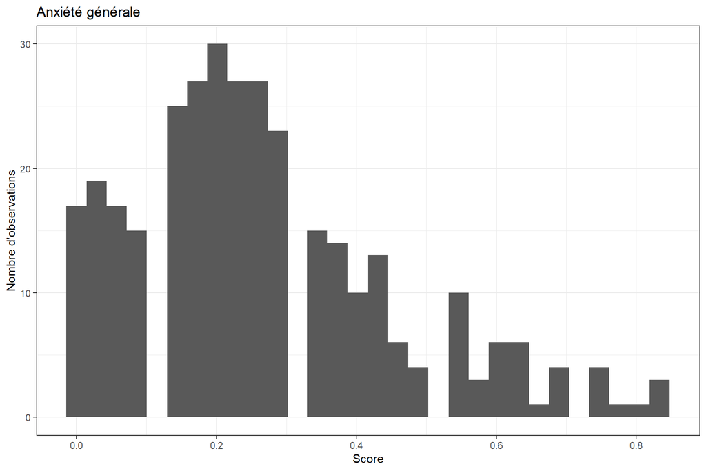

On remarque une anxiété pré-compétition très faible.

## Anxiété somatique

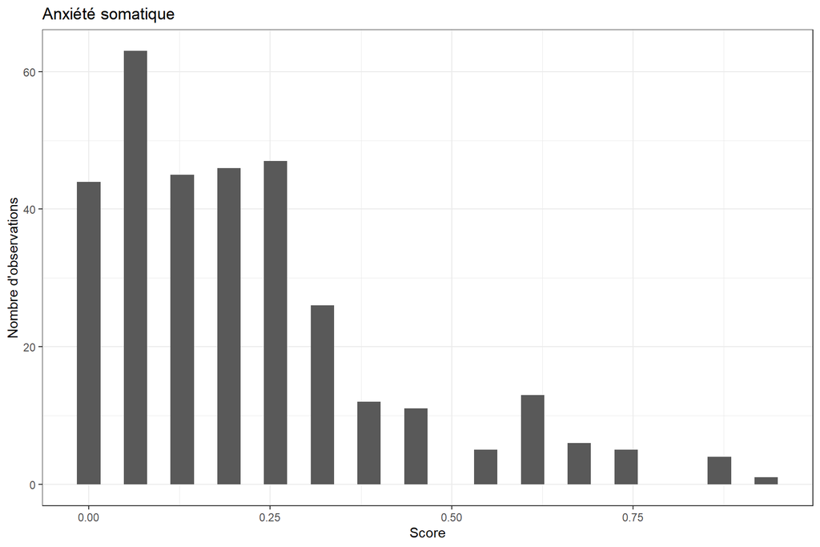

L’anxiété somatique des participants est assez faible.

## Anxiété cognitive

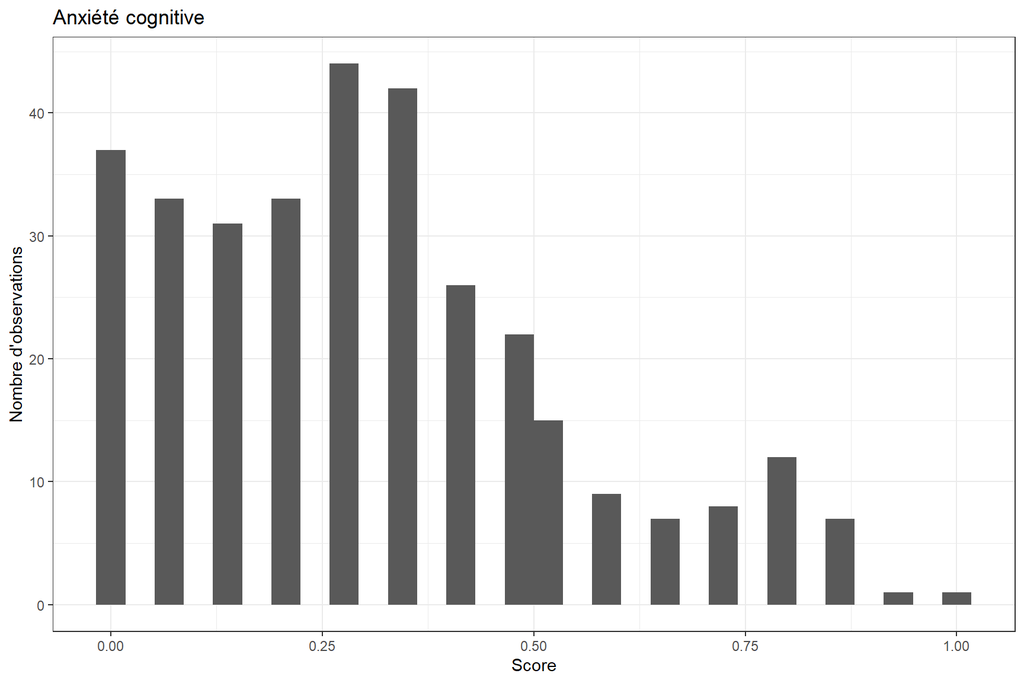

On remarque une anxiété cognitive faible.

## Passion harmonieuse

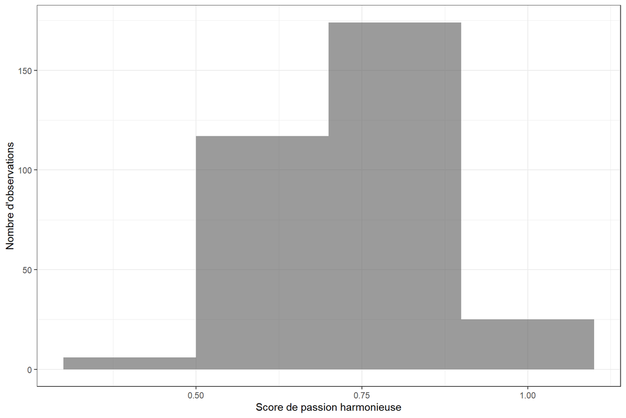

Représentation du score de passion harmonieuse

Il semblerait, que la pratique du trail soit globalement bien en harmonie avec la vie des répondants à ce questionnaire. Nous observons notamment un score minimal de 3/7.

## Passion obsessive

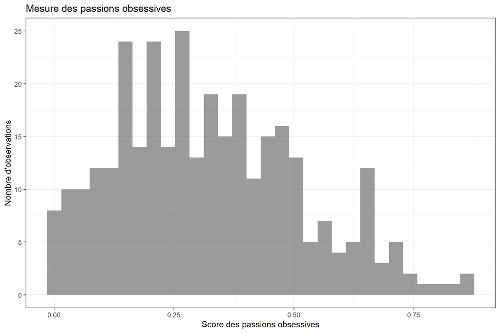

Cette passion pour le trail est d’une obsession moyenne. Elle est globalement faiblement obsessionnelle mais sa pratique reste mi-saine. Il y a peu de coureurs pour lesquels cette passion est extrêmement obsessive.

## Addiction

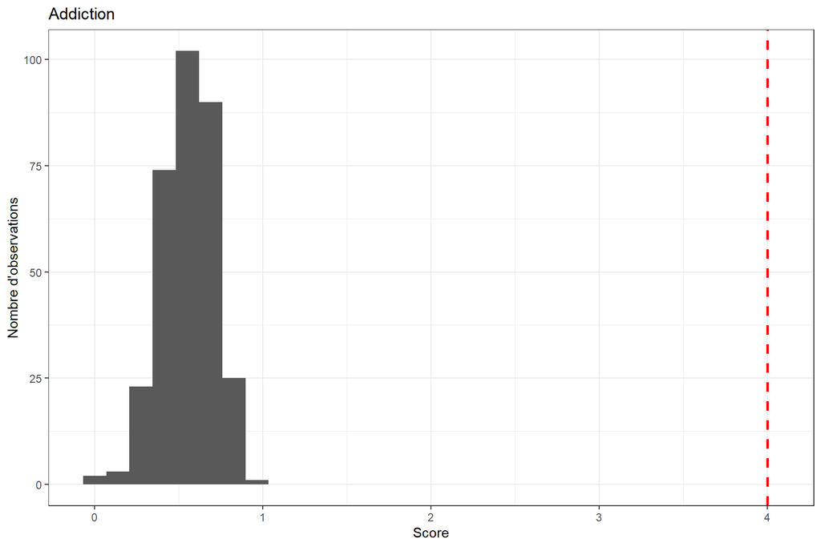